# API Documentation

### SignUp

- Back To Top

|  | ParameterName | Type | Description | Mandatory Parameter |
| --- | --- | --- | --- | --- |
| 1 | email | string | Email ID of the user | True |
| 2 | password | string | password for the user | True |
| 3 | name | string | username | True |
| 4 |  |  |  |  |

#### POST

Following are the methods to call the api using curl in Postman. Data is accepted in form format. please click on the data tab to get the details on the accepted data details.

##### cURL

```r
$ curl -X POST -H 'Content-Type: application/x-www-form-urlencoded' -d "name=testuser&email=abc@example.com&password=yourpassword@123" '<<baseurl>>:5001/signup'
```

##### Postman Application

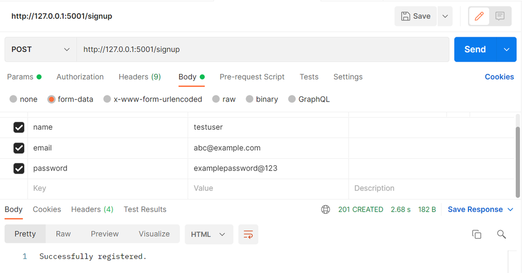

```r
knitr::include_graphics("./images/signup.png")
```

##### Response

```r
"Successfully registered."
```

##### Url

```r
<<base_url>>/signup
```

### Login

- Back To Top

The second step is to login with the application and generate token which can be used as authentication of apis in order to get the data.

|  | ParameterName | Type | Description | Mandatory Parameter |
| --- | --- | --- | --- | --- |
| 1 | email | string | Email ID of the user | True |
| 2 | password | string | password for the user | True |

#### POST

Following are the methods to call the api using curl and in Postman. Please click on the appropraite tab to see the details.

##### cURL

```r
$ curl -X POST -H 'Content-Type: application/x-www-form-urlencoded' -d "email=abc@example.com&password=yourpassword@123" '<<baseurl>>:5001/login'
```

##### Postman Application

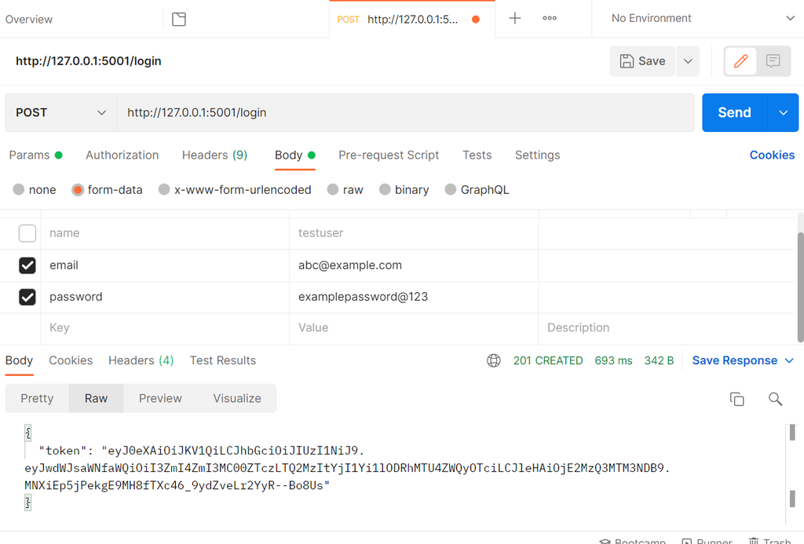

```r
knitr::include_graphics("./images/login.png")
```

##### Response

```r
{
  "token": "eyJ0eXAiOiJKV1QiLCJhbGciOiJIUzI1NiJ9.eyJwdWJsaWNfaWQiOiI3ZmI4ZmI3MC00ZTczLTQ2MzItYjI1Yi1lODRhMTU4ZWQyOTciLCJleHAiOjE2MzQ3MTM3NDB9.MNXiEp5jPekgE9MH8fTXc46_9ydZveLr2YyR--Bo8Us"
}
```

##### Url

```r
<<base_url>>/login
```

### User

- Back To Top

The third step is to use the token in header and to fetch the data from target api. For example, in the below example we have mentioned how to get the details.

#### GET

Following are the methods to call the api using curl and in Postman. Please click on the appropriate tab to see the details.

##### cURL

```r
curl -H "x-access-token:<<your recently generated token here; bydefault it is active only for 30 minutes>>" <base_url>:5001/user
```

##### Postman Application

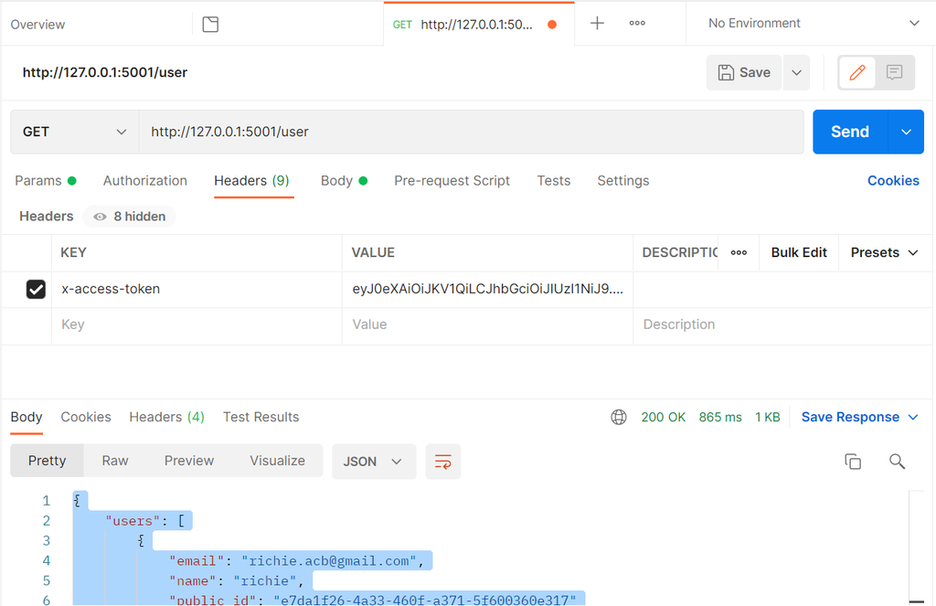

```r
knitr::include_graphics("./images/user.png")
```

##### Response

```r
{
    "users": [
        {
            "email": "richie.acb@gmail.com",
            "name": "richie",
            "public_id": "e7da1f26-4a33-460f-a371-5f600360e317"
        },
        {
            "email": "richie.chatterjee31@gmail.com",
            "name": "richie",
            "public_id": "e009cb3f-928a-473c-b995-80ed250a2942"
        },
        {
            "email": "richie.chatterjee32@gmail.com",
            "name": "testuser",
            "public_id": "9503c5ce-9c84-4fb7-acd0-856cd78344b6"
        },
        {
            "email": "richie.chatterjee35@gmail.com",
            "name": "testuser",
            "public_id": "d5123a79-0185-4545-91d5-2d96d8c8d97b"
        },
        {
            "email": "richie.chatterjee36@gmail.com",
            "name": "testuser",
            "public_id": "aa5d07a1-5ab1-47e9-a4b9-a4b0a876e68e"
        },
        {
            "email": "abc@example.com",
            "name": "testuser",
            "public_id": "7fb8fb70-4e73-4632-b25b-e84a158ed297"
        }
    ]
}
```

##### Url

```r
<<base_url>>/user
```

- Back To Top

Similarly, with token in header and params in request, /get_data for any table residing in the provided database can get fetched.

#### GET

Following are the methods to call the api using curl and in Postman. Please click on the appropriate tab to see the details.

##### cURL

```r
curl -H "x-access-token:<<your recently generated token here; bydefault it is active only for 30 minutes>>" http://127.0.0.1:5001/get_data?TableName=company_email1
```

##### Postman Application

[figure not shown]

```r
knitr::include_graphics("./images/get_data.png")
```

##### Response

```r
"{'col': [('Application_Date',), ('Company_Name',), ('Email_Address',), ('Location',)], 'data': [('Cognizant', 'Bangalore', 'karthick.chinnasamy@careernet.co.in', None), ('GradientM Consulting', 'Hyderabad', 'shilpa@gradientm.com', None), ('Aditech Concsulting', 'Hyderabad', 'priyanka@aditech.net', None), ('Gradient M', 'Hyderabad', 'kavya.reddy@gradientm.com', None), ('Orcapod Consulting', 'Hyderabad'.....}
```

##### Url

```r
<<base_url>>/get_data?TableName=company_email1
```